# immunotherapy_analysis

## Significant correlation between NES and ORR

We further investigate the relevance of neoantigen enrichment score in cancer immune therapy response prediction.

Load the pancancer ORR and view it:

```r
ORR <- readRDS("~/Immunoediting/data/Immunotherapy/ORR.rds") %>%
  select(-c(4:7))

##view data
DT::datatable(ORR,
  options = list(scrollX = TRUE, keys = TRUE), rownames = FALSE
)
```

| Cancer_Type | Pooled_ORR | PatientsNumber_ORR | cancer |
| --- | --- | --- | --- |
| Adrenocortical Carcinoma | 6 | 50 | TCGA-ACC |
| Anal Cancer | 24 | 37 |  |
| Breast Carcinoma | 6.18 | 312 | TCGA-BRCA |
| Cervical Cancer | 18.28 | 71 | TCGA-CESC |
| Cutaneous Squamous Cell Carcinoma | 47.3 | 95 |  |
| Endometrial Cancer | 13 | 15 | TCGA-UCEC |
| Esophagogastric Carcinoma | 10.69 | 702 | TCGA-STAD;TCGA-ESCA |
| Germ Cell Tumors | 0 | 12 | TCGA-TGCT |
| Glioblastoma | 9.43 | 183 | TCGA-GBM |
| Head and Neck | 15.39 | 432 | TCGA-HNSC |

[output cut: 17 more lines]

Then we add cancer type median NES(ccf) and NES(exp) based on TCGA data to this dataset, and calculate correlation between NES and ORR:

```r
pancancer_nes_ccf <- readRDS("~/Immunoediting/data/pancancer_nes_ccf.rds")
pancancer_nes_exp <- readRDS("~/Immunoediting/data/pancancer_nes_exp.rds")

pancancer_nes_ccf$cancer <- NeoEnrichment::getcancer_type(pancancer_nes_ccf$sample,cores = 2,par = TRUE)
```

```
#> you have 24 cores
```

```r
pancancer_nes_ccf$cancer <- ifelse(pancancer_nes_ccf$cancer %in% c("TCGA-STAD","TCGA-ESCA"),
                                                   "TCGA-STAD;TCGA-ESCA",
                                                   ifelse(pancancer_nes_ccf$cancer %in% c("TCGA-KIRC","TCGA-KIRP"),
                                                          "TCGA-KIRC;TCGA-KIRP",pancancer_nes_ccf$cancer))
luad_lusc <- pancancer_nes_ccf %>% filter(cancer %in% c("TCGA-LUAD","TCGA-LUSC")) %>%
  mutate(cancer="TCGA-LUAD;TCGA-LUSC")

pancancer_nes_ccf <- rbind(pancancer_nes_ccf,luad_lusc)

pancancer_nes_ccf %>% group_by(cancer) %>%
  summarise(median_es=median(nes),samples=n()) -> ccf_median_es
ORR_ccf <- left_join(ORR,ccf_median_es,by="cancer") %>% filter(!is.na(median_es))

cor.test(ORR_ccf$Pooled_ORR,ORR_ccf$median_es)
```

```
#>
#>  Pearson's product-moment correlation
#>
#> data:  ORR_ccf$Pooled_ORR and ORR_ccf$median_es
#> t = -3.2216, df = 20, p-value = 0.00428
#> alternative hypothesis: true correlation is not equal to 0
#> 95 percent confidence interval:
#>  -0.8071930 -0.2161627
#> sample estimates:
#>        cor
#> -0.5845019
```

The Pearson’s correlation coefficient is -0.58 and p value is 0.00428, showing that the NES(CCF) has a significant correlation with ORR.

Then we can plot this correlation:

```r
require(ggrepel)
require(scales)
```

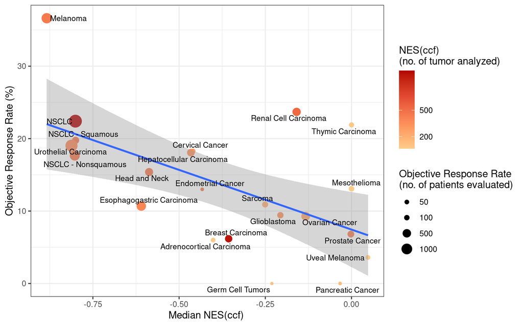

```r
p1 <- ggplot(ORR_ccf, aes(x = median_es, y = Pooled_ORR)) +
  geom_point(aes(color = samples, size = PatientsNumber_ORR)) +
  geom_smooth(method = "lm", se = T) +
  geom_text_repel(aes(label = Cancer_Type), size = 3) +
  labs(
    x = "Median NES(ccf) ", y = "Objective Response Rate (%)",
    size = "Objective Response Rate\n(no. of patients evaluated)",
    color = "NES(ccf)\n(no. of tumor analyzed)"
  ) +
  scale_size_continuous(breaks = c(50, 100, 500, 1000)) +
  scale_color_gradientn(
    colours = RColorBrewer::brewer.pal(5, name = "OrRd")[-1],
    breaks = c(50, 200, 500, 1000)
  ) +
  theme_bw()
p1
```

```r
#save_plot("~/Immunoediting/results/cor_nes_ccf_ORR.pdf", p1,base_height =6)
```

The same code can apply to NES(EXP):

```r
pancancer_nes_exp$cancer <- NeoEnrichment::getcancer_type(pancancer_nes_exp$sample,cores = 2,par = TRUE)
```

```
#> you have 24 cores
```

```r
pancancer_nes_exp$cancer <- ifelse(pancancer_nes_exp$cancer %in% c("TCGA-STAD","TCGA-ESCA"),
                                                   "TCGA-STAD;TCGA-ESCA",
                                                   ifelse(pancancer_nes_exp$cancer %in% c("TCGA-KIRC","TCGA-KIRP"),
                                                          "TCGA-KIRC;TCGA-KIRP",pancancer_nes_exp$cancer))
luad_lusc <- pancancer_nes_exp %>% filter(cancer %in% c("TCGA-LUAD","TCGA-LUSC")) %>%
  mutate(cancer="TCGA-LUAD;TCGA-LUSC")

pancancer_nes_exp <- rbind(pancancer_nes_exp,luad_lusc)

pancancer_nes_exp %>% group_by(cancer) %>%
  summarise(median_es=median(nes),samples=n()) -> exp_median_es
ORR_exp <- left_join(ORR,exp_median_es,by="cancer") %>% filter(!is.na(median_es))

cor.test(ORR_exp$Pooled_ORR,ORR_exp$median_es)
```

```
#>
#>  Pearson's product-moment correlation
#>
#> data:  ORR_exp$Pooled_ORR and ORR_exp$median_es
#> t = -1.5608, df = 20, p-value = 0.1343
#> alternative hypothesis: true correlation is not equal to 0
#> 95 percent confidence interval:
#>  -0.659503  0.106949
#> sample estimates:
#>        cor
#> -0.3295176
```

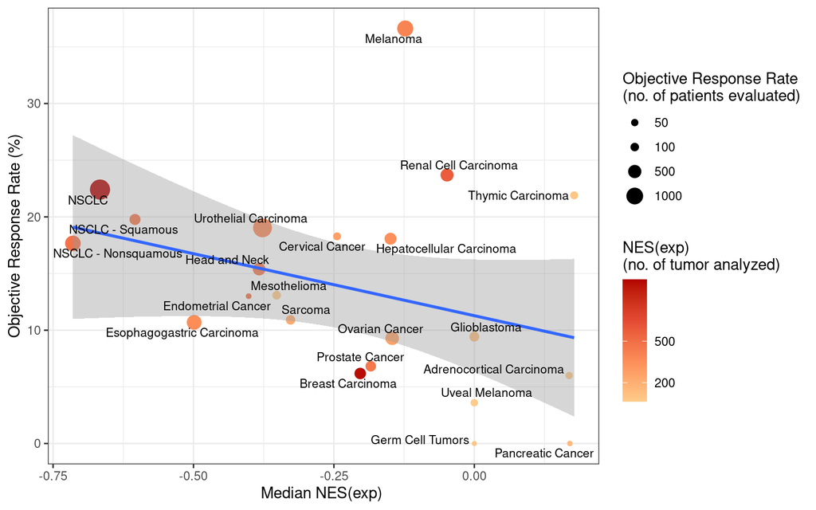

```r
require(ggrepel)
require(scales)

p2 <- ggplot(ORR_exp, aes(x = median_es, y = Pooled_ORR)) +
  geom_point(aes(color = samples, size = PatientsNumber_ORR)) +
  geom_smooth(method = "lm", se = T) +
  geom_text_repel(aes(label = Cancer_Type), size = 3) +
  labs(
    x = "Median NES(exp) ", y = "Objective Response Rate (%)",
    size = "Objective Response Rate\n(no. of patients evaluated)",
    color = "NES(exp)\n(no. of tumor analyzed)"
  ) +
  scale_size_continuous(breaks = c(50, 100, 500, 1000)) +
  scale_color_gradientn(
    colours = RColorBrewer::brewer.pal(5, name = "OrRd")[-1],
    breaks = c(50, 200, 500, 1000)
  ) +
  theme_bw()
p2
```

```r
#save_plot("~/Immunoediting/results/cor_nes_exp_ORR.pdf", p2,base_height =6)
```

In cancer types level significant associations between ES(ccf) and pan-cancer ORR has been observed. Suggesting neoantigen enrichment score could have predictive value in ICI response prediction

## Neoantigen enrichment score predict the clinical response of cancer immunotherapy

In public ICI datasets with available raw WES data and RNA-seq data, we calculate the neoantigen enrichment score for each patient and investigate diferent ICI response between NES negative and positive patients.

We firstly look at the survial of different group patients:

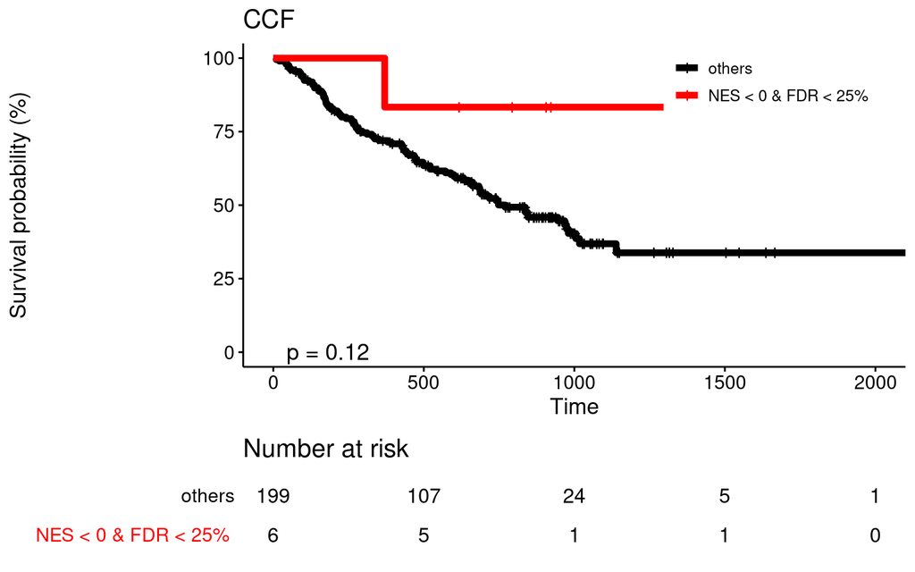

```r
all_clinical <- readRDS("~/Immunoediting/data/Immunotherapy/all_clinical.rds")
all_sample_nes_exp <- readRDS("~/Immunoediting/data/Immunotherapy/all_sample_nes_exp.rds")
all_sample_nes_ccf <- readRDS("~/Immunoediting/data/Immunotherapy/all_sample_nes_ccf.rds")

all_sample_nes_ccf <- left_join(all_sample_nes_ccf,all_clinical,by="sample") %>%
  mutate(p_adj=p.adjust(p_value,method = "fdr")) %>%
  mutate(es_type=case_when(
    nes<0 & p_adj<0.25 ~ "sig_negative",
    nes<0 & p_adj>0.25 ~ "negative but non-sig",
    nes>=0 ~"positive"
  ))%>%
  filter(!is.na(OS))
all_sample_nes_ccf <- all_sample_nes_ccf %>%
  mutate(es_type2=ifelse(nes<0 & p_adj<0.25,"sig_negative","others"),
         es_type3=ifelse(nes<0,"negative","positive"),
         es_type4=ifelse(nes<0 & p_value<0.1,"sig_negative","others"))

fit1 <- survfit(Surv(OS.time,OS)~es_type2,data = all_sample_nes_ccf)
p1 <- ggsurvplot(fit1,pval = T,risk.table = T,data = all_sample_nes_ccf,
                  tables.theme = theme_cleantable(),  # Clean risk table
                  palette =c("black","red"),
                  size=2,title="CCF", fun = "pct",
                 legend = c(0.8, 0.9), legend.title = element_blank(),
                 legend.labs = c("others", "NES < 0 & FDR < 25% "))
fit2 <- survfit(Surv(OS.time,OS)~es_type3,data = all_sample_nes_ccf)
p2 <- ggsurvplot(fit2,pval = T,risk.table = T,data = all_sample_nes_ccf,
                  tables.theme = theme_cleantable(),  # Clean risk table
                  palette =c("red","black"),
                  size=2,title="CCF", fun = "pct",
                 legend = c(0.8, 0.9), legend.title = element_blank(),
                 legend.labs = c("NES<0", "NES>0"))
p1
```

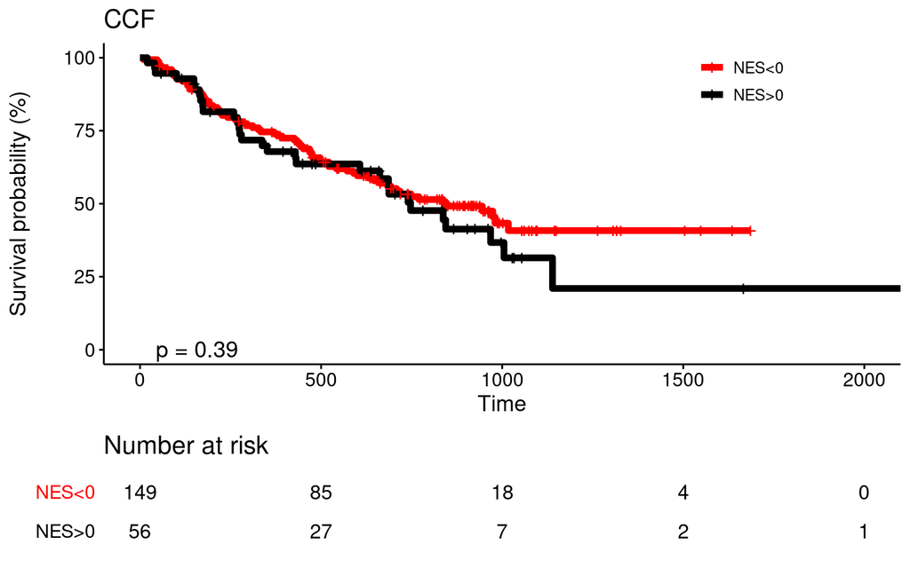

```r
p2
```

```r
#plot_res <- arrange_ggsurvplots(list(p1,p2),ncol=2)

#save_plot("~/Immunoediting/results/survial_immunotherapy_ccf.pdf", plot_res,
#          base_height = 7,base_width = 8,nrow = 1,ncol = 2)
```

This result shows that the group of NES < 0 has a better survial but is not significant.

Then we could use fisher test to exam the different ICI response of NES groups:

```r
##function to view fisher test results
plot_fisher <- function(dt,OR,P){
  a <- ggplot(data=dt,mapping = aes(x=response2,y=value,fill=type))+
    geom_bar(stat = "identity",position="dodge")+
    theme(panel.grid =element_blank(),
          panel.border = element_blank(),
          axis.ticks = element_blank(),
          axis.title=element_blank(),
          axis.text.y= element_blank(),
          panel.background = element_blank()) +
    geom_text(aes(label=value),
              stat = "identity",position=position_dodge(width=0.9), vjust=-0.25)+
    scale_x_discrete(labels=c(paste("No Response\n","(n=",
                   sum(dt[dt$response2=="no_response","value"]),")"),
             paste("Response\n","(n=",
                   sum(dt[dt$response2=="response","value"]),")")))+
    labs(title = paste0("Fisher's Exact Test: OR = ",OR,", P = ",P))
  return(a)
}

all_sample_nes_ccf %>%
  group_by(response2) %>%
  summarise(negative=sum(es_type3=="negative"),
            positive=sum(es_type3=="positive"))-> c
##view
DT::datatable(c,
  options = list(scrollX = TRUE, keys = TRUE), rownames = FALSE
)
```

| response2 | negative | positive |
| --- | --- | --- |
| no_response | 87 | 42 |
| response | 62 | 14 |

```r
##do fisher
fisher.test(cbind(c(87,42),c(62,14)))
```

```
#>
#>  Fisher's Exact Test for Count Data
#>
#> data:  cbind(c(87, 42), c(62, 14))
#> p-value = 0.0347
#> alternative hypothesis: true odds ratio is not equal to 1
#> 95 percent confidence interval:
#>  0.2172071 0.9679393
#> sample estimates:
#> odds ratio
#>  0.4694055
```

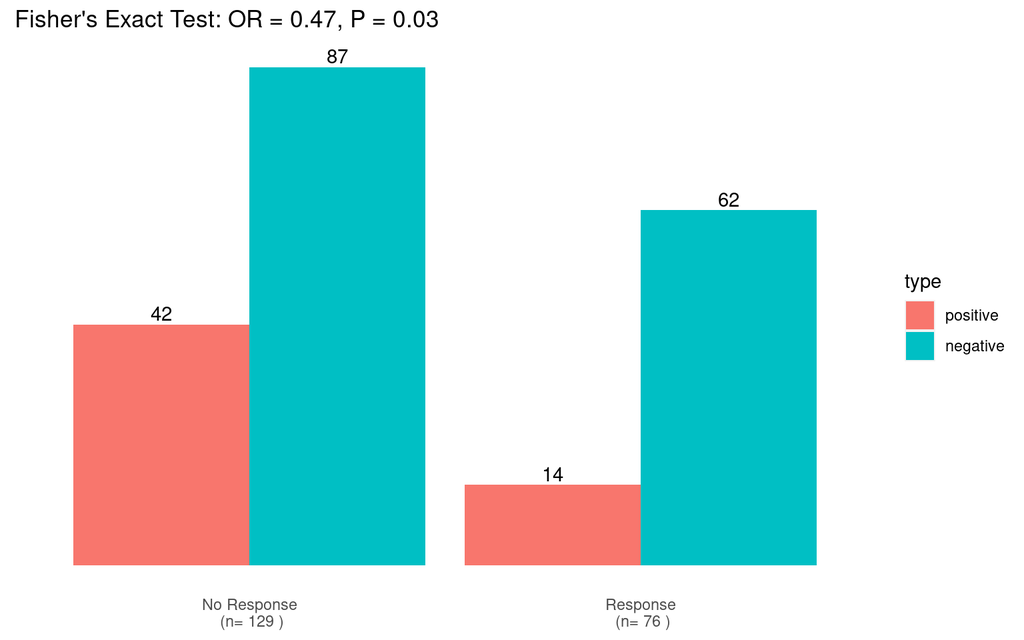

```r
c <- c %>%
  pivot_longer(cols = c("negative","positive"),names_to="type",values_to="value")
c$type <- factor(c$type,levels = c("positive","negative"))
p_fisher <- plot_fisher(c,OR = 0.47,P=0.03)
p_fisher
```

```r
all_sample_nes_ccf %>%
  group_by(response2) %>%
  summarise(sig_negative=sum(es_type2=="sig_negative"),
            others=sum(es_type2=="others"))-> c1

DT::datatable(c1,
  options = list(scrollX = TRUE, keys = TRUE), rownames = FALSE
)
```

| response2 | sig_negative | others |
| --- | --- | --- |
| no_response | 1 | 128 |
| response | 5 | 71 |

```r
fisher.test(cbind(c(1,128),c(5,71)))
```

```
#>
#>  Fisher's Exact Test for Count Data
#>
#> data:  cbind(c(1, 128), c(5, 71))
#> p-value = 0.02717
#> alternative hypothesis: true odds ratio is not equal to 1
#> 95 percent confidence interval:
#>  0.002333085 1.029425347
#> sample estimates:
#> odds ratio
#>  0.1120608
```

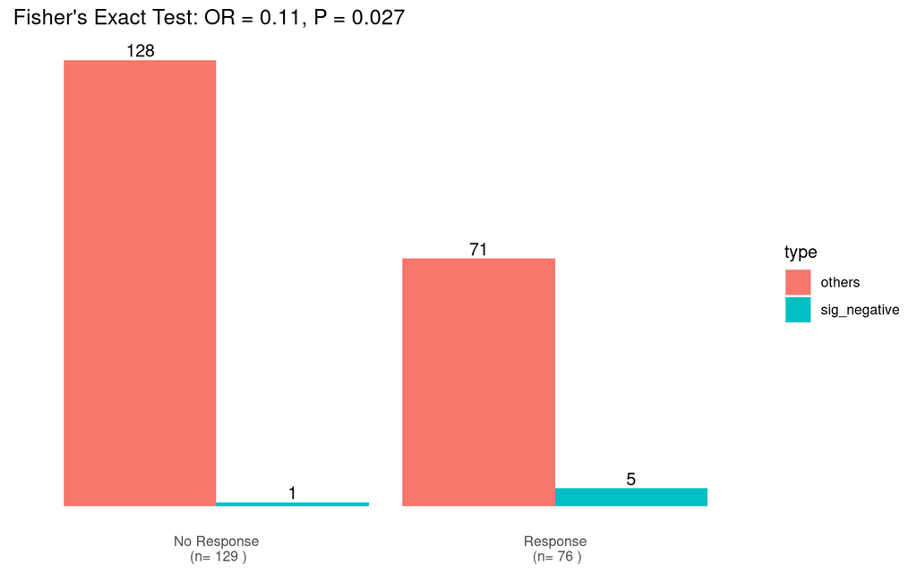

```r
c1 <- c1 %>%
  pivot_longer(cols = c("sig_negative","others"),names_to="type",values_to="value")
p_fisher1 <- plot_fisher(c1,OR=0.11,P=0.027)
p_fisher1
```

From the fisher test, we can see the group of NES<0 (significant or not significant) is enrich in Response group.